# 8.3. The `data.table` Package

The package `data.table` facilitates aggregation/summarization of large data *in memory*.

It provides for SQL-like operations on `data.table` objects which behave like `data.frames`, except with far, far, better performance.

```r
data(mtcars)
class(mtcars)
```

```
## [1] "data.frame"
```

Convert data frames to data table using `data.table` or `as.data.table`.

```r
mtcarsDT <- data.table(mtcars)
mtcarsDT[
         mpg > 20,                             ## the i part
         .(AvgHP = mean(hp),                   ## the j part
           "MinWT(kg)" = min(wt * 453.6)),     ## 1000 lbs = 453.6 Kg
         by = .(cyl, under5gears = gear < 5)   ## the group by part
         ]
```

```
##    cyl under5gears     AvgHP MinWT(kg)
## 1:   6        TRUE 110.00000 1188.4320
## 2:   4        TRUE  78.33333  732.5640
## 3:   4       FALSE 102.00000  686.2968
```

# 8.3.1. Basic Idea

Data table operations can be thought to have three components: `i`, `j`, `by` corresponding to `where`, `select` and `group by` inspired by SQL.

```
R         i        j          by
```

SQL where select group by

So `DT[i, j, by]` means: take `DT`, subset rows using `i`, then calculate `j` grouped by `by`.

In `data.table` character vectors are best used as is for efficiency.

# 8.3.2. Compare and Contrast with data frames

```r
d <- data.frame(x = letters[1:5], y = 1:5, z = TRUE)
str(d)
```

```
## 'data.frame':    5 obs. of  3 variables:
##  $ x: Factor w/ 5 levels "a","b","c","d",..: 1 2 3 4 5
##  $ y: int  1 2 3 4 5
##  $ z: logi  TRUE TRUE TRUE TRUE TRUE
```

with

```r
DT <- data.table(x = letters[1:5], y = 1:5, z = TRUE)
str(DT)
```

```
## Classes 'data.table' and 'data.frame':   5 obs. of  3 variables:
##  $ x: chr  "a" "b" "c" "d" ...
##  $ y: int  1 2 3 4 5
##  $ z: logi  TRUE TRUE TRUE TRUE TRUE
##  - attr(*, ".internal.selfref")=<externalptr>
```

```r
## data frame does not allow the next statement
d[3:5]
```

```
## Error in `[.data.frame`(d, 3:5): undefined columns selected
```

```r
## data.table does, where the 3:5 becomes the "i"
DT[3:5]
```

```
##    x y    z
## 1: c 3 TRUE
## 2: d 4 TRUE
## 3: e 5 TRUE
```

```r
## The next two are similar
d[3:5, ]
```

```
##   x y    z
## 3 c 3 TRUE
## 4 d 4 TRUE
## 5 e 5 TRUE
```

```r
DT[3:5, ]
```

```
##    x y    z
## 1: c 3 TRUE
## 2: d 4 TRUE
## 3: e 5 TRUE
```

```r
## The last row of DT
DT[.N]
```

```
##    x y    z
## 1: e 5 TRUE
```

The special variable `.N` refers to the number of rows (in a specific context).

# 8.3.3. Selecting columns in `j`

```r
DT <- data.table(A = 1:5, B = letters[1:5], C = 6:10)
DT[, B]
```

```
## [1] "a" "b" "c" "d" "e"
```

*Note how the returned value is a vector, not another data table (as with tibbles).* To force it to be a data table, use the `list` construct `.()`.

```r
DT[, .(B, C)]
```

```
##    B  C
## 1: a  6
## 2: b  7
## 3: c  8
## 4: d  9
## 5: e 10
```

```r
DT[, .(Total = sum(A), Mean = mean(C))]
```

```
##    Total Mean
## 1:    15    8
```

```r
DT[, .(B, C = sum(C))]
```

```
##    B  C
## 1: a 40
## 2: b 40
## 3: c 40
## 4: d 40
## 5: e 40
```

The construct `.()` is an alias for `list()`, therefore you can stick in arbitary expressions. These will be evaluated in the context of the data table variables, so no need to qualify with `$`.

Note how the fact that `data.table` does not return a `data.table` as a result (when a list construct is not used) can be exploited for side effects.

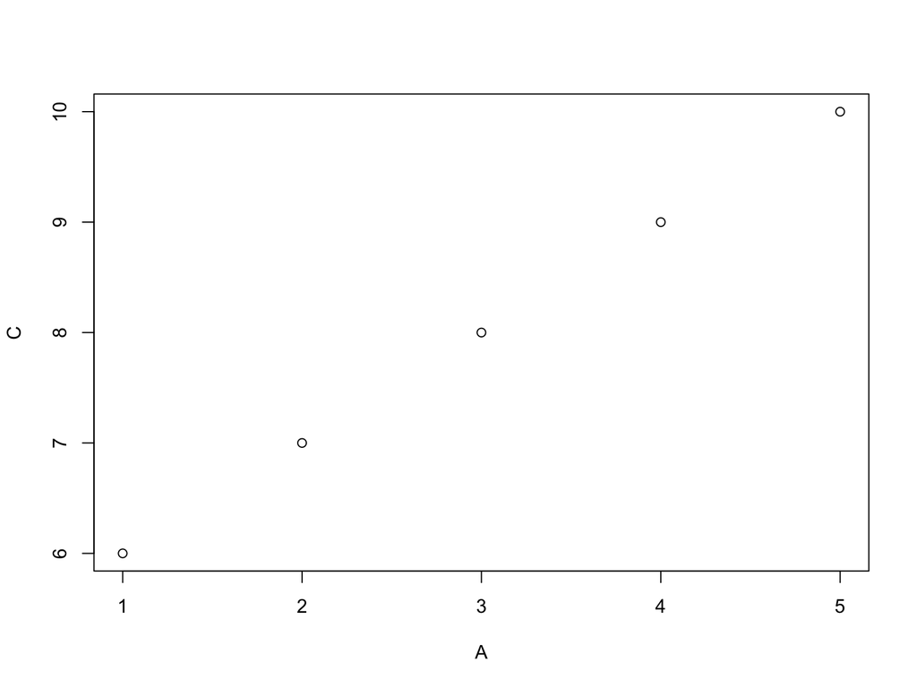

```r
DT[, plot(A, C)]
```

# 8.3.4. Grouping

Compute some grouped statistics.

```r
DT <- data.table(x = sample(letters[1:5], 10, replace = TRUE), y = 1:10)
DT
```

```
##     x  y
##  1: b  1
##  2: d  2
##  3: b  3
##  4: e  4
##  5: b  5
##  6: c  6
##  7: d  7
##  8: a  8
##  9: c  9
## 10: e 10
```

```r
DT[, .(sumY = sum(y), meanY = mean(y)), by = .(x)]
```

```
##    x sumY meanY
## 1: b    9   3.0
## 2: d    9   4.5
## 3: e   14   7.0
## 4: c   15   7.5
## 5: a    8   8.0
```

The grouping preserves the order in which the groups are seen. Also, the group is returned first, followed by the quantities computed. Other columns are dropped.

Suppose, for the sum and mean example, we also want the count of how many in each group.

```r
DT[, .(sumY = sum(y), meanY = mean(y), count = .N), by = .(x)]
```

```
##    x sumY meanY count
## 1: b    9   3.0     3
## 2: d    9   4.5     2
## 3: e   14   7.0     2
## 4: c   15   7.5     2
## 5: a    8   8.0     1
```

Here `.N` refers to the number in the subset, the context!

Beware of recycling:

```r
DT[, .(cumsumY = cumsum(y), meanY = mean(y)), by = .(x)]
```

```
##     x cumsumY meanY
##  1: b       1   3.0
##  2: b       4   3.0
##  3: b       9   3.0
##  4: d       2   4.5
##  5: d       9   4.5
##  6: e       4   7.0
##  7: e      14   7.0
##  8: c       6   7.5
##  9: c      15   7.5
## 10: a       8   8.0
```

The grouping can be done by arbitrary functions.

```r
DT[, .(sumY = sum(y), meanY = mean(y), count = .N), by = .( belowD = x < 'd')]
```

```
##    belowD sumY    meanY count
## 1:   TRUE   32 5.333333     6
## 2:  FALSE   23 5.750000     4
```

Here is another example with the `iris` dataset.

```r
str(iris)
```

```
## 'data.frame':    150 obs. of  5 variables:
##  $ Sepal.Length: num  5.1 4.9 4.7 4.6 5 5.4 4.6 5 4.4 4.9 ...
##  $ Sepal.Width : num  3.5 3 3.2 3.1 3.6 3.9 3.4 3.4 2.9 3.1 ...
##  $ Petal.Length: num  1.4 1.4 1.3 1.5 1.4 1.7 1.4 1.5 1.4 1.5 ...
##  $ Petal.Width : num  0.2 0.2 0.2 0.2 0.2 0.4 0.3 0.2 0.2 0.1 ...
##  $ Species     : Factor w/ 3 levels "setosa","versicolor",..: 1 1 1 1 1 1 1 1 1 1 ...
```

Suppose we want medians by species.

```r
DT <- as.data.table(iris)
DT[, .(Sepal.length = median(Sepal.Length),
       Sepal.Width = median(Sepal.Width),
       Petal.length = median(Petal.Length),
       Petal.Width = median(Petal.Width)),
   by = Species]
```

```
##       Species Sepal.length Sepal.Width Petal.length Petal.Width
## 1:     setosa          5.0         3.4         1.50         0.2
## 2: versicolor          5.9         2.8         4.35         1.3
## 3:  virginica          6.5         3.0         5.55         2.0
```

To sort in decreasing order of `Species`, use *chaining*.

```r
DT[, .(Sepal.length = median(Sepal.Length),
       Sepal.Width = median(Sepal.Width),
       Petal.length = median(Petal.Length),
       Petal.Width = median(Petal.Width)),
   by = Species][order(-Species)]
```

```
##       Species Sepal.length Sepal.Width Petal.length Petal.Width
## 1:  virginica          6.5         3.0         5.55         2.0
## 2: versicolor          5.9         2.8         4.35         1.3
## 3:     setosa          5.0         3.4         1.50         0.2
```

This is equivalent to:

```r
tmp <- DT[, .(Sepal.length = median(Sepal.Length),
              Sepal.Width = median(Sepal.Width),
              Petal.length = median(Petal.Length),
              Petal.Width = median(Petal.Width)),
          by = Species]
tmp[i = order(-Species)]
```

```
##       Species Sepal.length Sepal.Width Petal.length Petal.Width
## 1:  virginica          6.5         3.0         5.55         2.0
## 2: versicolor          5.9         2.8         4.35         1.3
## 3:     setosa          5.0         3.4         1.50         0.2
```

Chaining is the process of doing two or more things in *one* statement. The advantage of this is that optimizations may be performed before the task is actually executed.

Note that the following is incorrect!

```r
DT[, .(Sepal.length = median(Sepal.Length),
       Sepal.Width = median(Sepal.Width),
       Petal.length = median(Petal.Length),
       Petal.Width = median(Petal.Width)),
   by = Species[order(Species, decreasing=TRUE)]]
```

```
##       Species Sepal.length Sepal.Width Petal.length Petal.Width
## 1:  virginica          5.0         3.4         1.50         0.2
## 2: versicolor          5.9         2.8         4.35         1.3
## 3:     setosa          6.5         3.0         5.55         2.0
```

Why??

Because that is equivalent to:

```r
tmp <-  DT[, j = Species[order(Species, decreasing = TRUE)]]

DT[, .(Sepal.length = median(Sepal.Length),
       Sepal.Width = median(Sepal.Width),
       Petal.length = median(Petal.Length),
       Petal.Width = median(Petal.Width)),
   by = tmp]
```

```
##           tmp Sepal.length Sepal.Width Petal.length Petal.Width
## 1:  virginica          5.0         3.4         1.50         0.2
## 2: versicolor          5.9         2.8         4.35         1.3
## 3:     setosa          6.5         3.0         5.55         2.0
```

# 8.3.5. Adding/Dropping Columns

You can add and drop columns (by reference) using the `:=` function.

```r
DT <- data.table(A = c(rep('a', 3), rep('b', 2)), B = 1:5)
DT[, C := B + 1]
DT
```

```
##    A B C
## 1: a 1 2
## 2: a 2 3
## 3: a 3 4
## 4: b 4 5
## 5: b 5 6
```

```r
DT[, `:=`(D = 2 * B, E = 2 * B + 1)]
DT[, `:=`(D = NULL, E=NULL)]
```

This is a very efficient and quick way of creating columns on the fly. Also, since this is done by reference, it is very efficient.

To examine this, let us see what happens when we do the same operations on a standard data frame or even a `tibble`, when we create a new column or drop it.

### First data frame.

```r
DF <- data.frame(A = c(rep('a', 3), rep('b', 2)), B = 1:5, stringsAsFactors = FALSE)
data.table::address(DF)
```

```
## [1] "0x7f85974e1648"
```

```r
DF$C <- DF$B + 1
str(DF)
```

```
## 'data.frame':    5 obs. of  3 variables:
##  $ A: chr  "a" "a" "a" "b" ...
##  $ B: int  1 2 3 4 5
##  $ C: num  2 3 4 5 6
```

```r
data.table::address(DF)
```

```
## [1] "0x7f85952d7b38"
```

```r
DF$C <- NULL
str(DF)
```

```
## 'data.frame':    5 obs. of  2 variables:
##  $ A: chr  "a" "a" "a" "b" ...
##  $ B: int  1 2 3 4 5
```

```r
data.table::address(DF)
```

```
## [1] "0x7f85946d3708"
```

*The address changed, which means things get copied*.

### Then `tibble`.

```r
library(tibble)
TB <- as_tibble(DF)
str(TB)
```

```
## Classes 'tbl_df', 'tbl' and 'data.frame':    5 obs. of  2 variables:
##  $ A: chr  "a" "a" "a" "b" ...
##  $ B: int  1 2 3 4 5
```

```r
data.table::address(TB)
```

```
## [1] "0x7f85959eabc8"
```

```r
TB$C <- TB$B + 1
str(TB)
```

```
## Classes 'tbl_df', 'tbl' and 'data.frame':    5 obs. of  3 variables:
##  $ A: chr  "a" "a" "a" "b" ...
##  $ B: int  1 2 3 4 5
##  $ C: num  2 3 4 5 6
```

```r
data.table::address(TB)
```

```
## [1] "0x7f85980d6df8"
```

```r
TB$C <- NULL
str(TB)
```

```
## Classes 'tbl_df', 'tbl' and 'data.frame':    5 obs. of  2 variables:
##  $ A: chr  "a" "a" "a" "b" ...
##  $ B: int  1 2 3 4 5
```

```r
data.table::address(TB)
```

```
## [1] "0x7f858fad3948"
```

### Now `data.table`.

```r
DT <- as.data.table(DF)
str(DT)
```

```
## Classes 'data.table' and 'data.frame':   5 obs. of  2 variables:
##  $ A: chr  "a" "a" "a" "b" ...
##  $ B: int  1 2 3 4 5
##  - attr(*, ".internal.selfref")=<externalptr>
```

```r
data.table::address(DT)
```

```
## [1] "0x7f859b1fe000"
```

As an aside, note that the next statement below is not what we want.

```r
DT[, .(C = B + 1)]
```

```
##    C
## 1: 2
## 2: 3
## 3: 4
## 4: 5
## 5: 6
```

```r
str(DT)
```

```
## Classes 'data.table' and 'data.frame':   5 obs. of  2 variables:
##  $ A: chr  "a" "a" "a" "b" ...
##  $ B: int  1 2 3 4 5
##  - attr(*, ".internal.selfref")=<externalptr>
```

It returns a result we don’t seek.

So let us create the `C` column, *in place.*

```r
data.table::address(DT)
```

```
## [1] "0x7f859b1fe000"
```

```r
DT[, `:=`(C = B + 1)]
str(DT)
```

```
## Classes 'data.table' and 'data.frame':   5 obs. of  3 variables:
##  $ A: chr  "a" "a" "a" "b" ...
##  $ B: int  1 2 3 4 5
##  $ C: num  2 3 4 5 6
##  - attr(*, ".internal.selfref")=<externalptr>
```

```r
data.table::address(DT)
```

```
## [1] "0x7f859b1fe000"
```

We remove it.

```r
DT[, C := NULL]
str(DT)
```

```
## Classes 'data.table' and 'data.frame':   5 obs. of  2 variables:
##  $ A: chr  "a" "a" "a" "b" ...
##  $ B: int  1 2 3 4 5
##  - attr(*, ".internal.selfref")=<externalptr>
```

```r
data.table::address(DT)
```

```
## [1] "0x7f859b1fe000"
```

No change to the memory address.

# 8.3.6. Keys

You can set keys on columns to make grouping operations faster. The indexing is done on the fly.

```r
DT <- data.table(A = c("c", "b", "a", "c", "b", "a"),
                 B = c(4, 1, 6, 3, 5, 2),
                 C = 1:6)
setkey(DT, A, B)
DT
```

```
##    A B C
## 1: a 2 6
## 2: a 6 3
## 3: b 1 2
## 4: b 5 5
## 5: c 3 4
## 6: c 4 1
```

You can then do things like

- Give me rows that match the key pair `A = "b"` and `B = 5`.

```r
DT[.("b", 5)]
```

```
##    A B C
## 1: b 5 5
```

- Give me rows that match the key value `A = "b"`

```r
DT[.("b")]
```

```
##    A B C
## 1: b 1 2
## 2: b 5 5
```

```r
DT[.("b", 6)]
```

```
##    A B  C
## 1: b 6 NA
```

- Problematic result for key value not in data

```r
DT[.("b", 7)]
```

```
##    A B  C
## 1: b 7 NA
```

The latter two examples can cause problems of program correctness, so I suggest using

```r
DT[.("b", 7), nomatch=0]
```

```
## Empty data.table (0 rows and 3 cols): A,B,C
```

Keying (or indexing) speeds up computations on large datasets significantly.

# 8.3.7 Miscellaneous

There are number of special variables such as `.SD` and `.SDcols` that can be exploited for computations. Briefly, `.SD` stands for *subset of data* and is the subset obtained by some grouping operation. You can exploit that fact with the `.()` construct in `j` to do arbitrary things.

The package also provides a fast function for reading data files called `fread`. Note, however, that it does not do the hand-holding that functions in `readr` do.

# 8.3.8. References

Read more in help for `data.table` and also the vignettes.

```r
vignette(package = "data.table")
```

will list them as well as a faq. Also see stackoverflow for common questions on `data.table`.